# Practical Machine Learning Course Project

DGiannis

October 19, 2020

# Project Background-Scope and Objective

Using devices such as Jawbone Up, Nike FuelBand, and Fitbit it is now possible to collect a large amount of data about personal activity relatively inexpensively. These type of devices are part of the quantified self movement – a group of enthusiasts who take measurements about themselves regularly to improve their health, to find patterns in their behavior, or because they are tech geeks. One thing that people regularly do is quantify how much of a particular activity they do, but they rarely quantify how well they do it. In this project, your goal will be to use data from accelerometers on the belt, forearm, arm, and dumbell of 6 participants. They were asked to perform barbell lifts correctly and incorrectly in 5 different ways. More information is available from the website here: http://groupware.les.inf.puc-rio.br/har (see the section on the Weight Lifting Exercise Dataset).

The goal of this analysis is to predict the manner in which they did the exercise. This is the “classe” variable in the training set.

# Data Source

The training data for this project are available here:

https://d396qusza40orc.cloudfront.net/predmachlearn/pml-training.csv

The test data are available here:

https://d396qusza40orc.cloudfront.net/predmachlearn/pml-testing.csv

# Outline of the approach

##### Based on the scope, this is a classification problem so we are going to implement three indicative methods and will indentify which one is the most proper for the specific data. Finally, we will apply the best method on the testing dataset to make predictions. More speciffically,the outline process will be as follows:

##### -Loading the Data

##### -Data preprocessing

##### -Create partision in the training set - cross validation

##### -Applying Classification Tree

##### -Applying Random Forest

##### -Applying Generalized Boosted

##### -Model Comparison

# Loading the Data

### loading the training data set

```r
url_training <- "https://d396qusza40orc.cloudfront.net/predmachlearn/pml-training.csv"
download.file(url_training, destfile = "pml-training.csv")
training = read.csv("pml-training.csv")
```

### loading the testing data set

```r
url_test <- "https://d396qusza40orc.cloudfront.net/predmachlearn/pml-testing.csv"
download.file(url_test, destfile = "pml-testing.csv")
testing = read.csv("pml-testing.csv")
```

# Data preprocessing

##### Removing NAs, near to zero variables and then also drop irrelevant columns (non-numeric) like user_name etc.

```r
library(caret)

## remove NAs

training = read.csv("pml-training.csv", na.strings = c("","NA","#DIV/0!"))
testing = read.csv("pml-testing.csv",na.strings = c("","NA","#DIV/0!"))

training<-training[,colSums(is.na(training)) == 0]
testing <-testing[,colSums(is.na(testing)) == 0]

## remove near to zero variables

non_zero_var <- nearZeroVar(training)
training_data <- training[,-non_zero_var]
testing_data <- testing[,-non_zero_var]

## remove irrelevant variables
training_data <- training_data[,8:59]
testing_data <- testing_data[,8:59]

dim(training_data);dim(testing_data)
```

```
## [1] 19622    52
```

```
## [1] 20 52
```

# Create partision in the training set - cross validation

##### We will split now the initial training set in 2 parts, the train set from where the methods will learn and the test set for cross validation in order to identidy which of the three methods perform better in this specific project by measuring the out of sample error each time

```r
set.seed(999)

inTrain <- createDataPartition(training_data$classe, p=0.8, list=FALSE)
train <- training_data[inTrain,]
test <- training_data[-inTrain,]

dim(train);dim(test)
```

```
## [1] 15699    52
```

```
## [1] 3923   52
```

# Applying Classification Tree

```r
CT_fit <- train(classe ~ ., data = train, method="rpart")

CT_prediction <- predict(CT_fit, test)
confusionMatrix(CT_prediction, test$classe)
```

```
## Confusion Matrix and Statistics
##
##           Reference
## Prediction    A    B    C    D    E
##          A 1014  299  319  290  200
##          B   18  267   13  112  132
##          C   56   84  297  102   97
##          D   26  109   55  139  109
##          E    2    0    0    0  183
##
## Overall Statistics
##
##                Accuracy : 0.4843
##                  95% CI : (0.4686, 0.5001)
##     No Information Rate : 0.2845
##     P-Value [Acc > NIR] : < 2.2e-16
##
##                   Kappa : 0.3252
##
##  Mcnemar's Test P-Value : < 2.2e-16
##
## Statistics by Class:
##
##                      Class: A Class: B Class: C Class: D Class: E
## Sensitivity            0.9086  0.35178  0.43421  0.21617  0.25381
## Specificity            0.6053  0.91308  0.89534  0.90884  0.99938
## Pos Pred Value         0.4779  0.49262  0.46698  0.31735  0.98919
## Neg Pred Value         0.9434  0.85448  0.88226  0.85538  0.85607
## Prevalence             0.2845  0.19347  0.17436  0.16391  0.18379
## Detection Rate         0.2585  0.06806  0.07571  0.03543  0.04665
## Detection Prevalence   0.5409  0.13816  0.16212  0.11165  0.04716
## Balanced Accuracy      0.7569  0.63243  0.66477  0.56251  0.62659
```

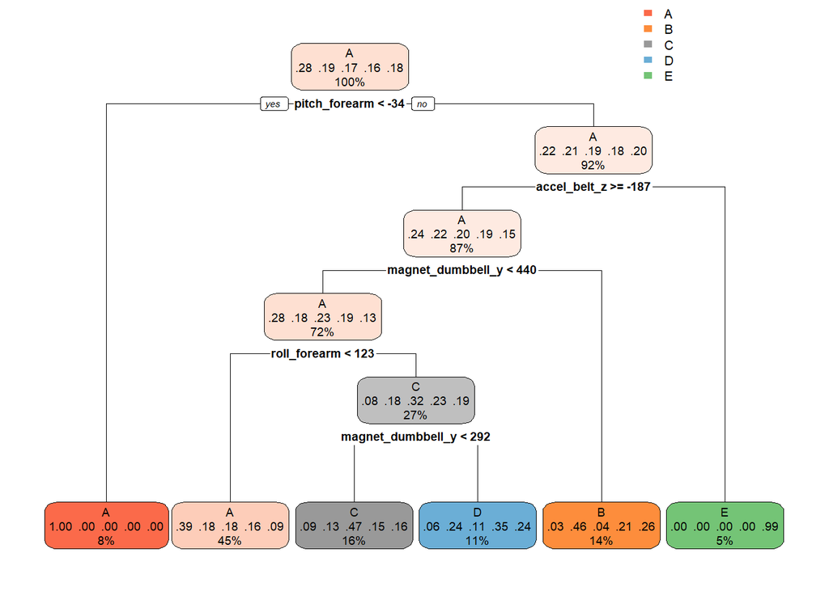

```r
library("rpart.plot")
rpart.plot(CT_fit$finalModel)
```

##### It is evident that Classification Tree model does not perform well as the accuraccy is very low (~ 48%). In other words the error in the test set (out of sample error) is high (~52%)